# Melbourne Housing Market

# Abstract

In this project, we will use Linear Regression, Decision Tree and Random Forests to predict the price of a home in Melbourne, Australia.

The metric used to determine *good-fit* of the model is RMSE, which determines the standard deviation of the average distance of a data point from the predicted values.

The dataset can be found on [Kaggle](https://www.kaggle.com/anthonypino/melbourne-housing-market#MELBOURNE_HOUSE_PRICES_LESS.csv).

# The Data

Load libraries used for this project.

```r
# Data manipulation and modeling
library(dplyr)
library(caret)
library(ranger)
library(rpart)

# Visuals
library(ggplot2)
library(cowplot)
library(sf)
library(rnaturalearth)
library(rnaturalearthdata)
library(rgeos)
library(corrplot)
```

Load dataset.

```r
housingPrices <- read.csv("Melbourne_housing_FULL.csv")
head(housingPrices, 2)
```

```
##       Suburb       Address Rooms Type   Price Method SellerG      Date
## 1 Abbotsford 68 Studley St     2    h      NA     SS  Jellis 3/09/2016
## 2 Abbotsford  85 Turner St     2    h 1480000      S  Biggin 3/12/2016
##   Distance Postcode Bedroom2 Bathroom Car Landsize BuildingArea YearBuilt
## 1      2.5     3067        2        1   1      126           NA        NA
## 2      2.5     3067        2        1   1      202           NA        NA
##          CouncilArea Lattitude Longtitude            Regionname
## 1 Yarra City Council  -37.8014   144.9958 Northern Metropolitan
## 2 Yarra City Council  -37.7996   144.9984 Northern Metropolitan
##   Propertycount
## 1          4019
## 2          4019
```

This is the data that we will be using for modeling. A few things to note:

- There are 34857 observations with 21 variables.
- This data does contain missing values.

Features that were removed:

- Suburb, Address, Postcode, Lattitude, Longitude
  - These feature was removed because of the increase in model complexity. Since there are other variables that take into account location, such as Region. Reducing the complexity of the model allows for more generalized interpretations.
- Method, SellerG, Date
  - These variables are not applicable to the goal of the project.
- Propertycount
  - This variable counted the number of properties in the region. Can be accounted for by regions.

# Analysis of the Data

## Basic Statistics

```r
summary(housingPrices)
```

[output not shown]

## Graphing of Features

### Graph 1

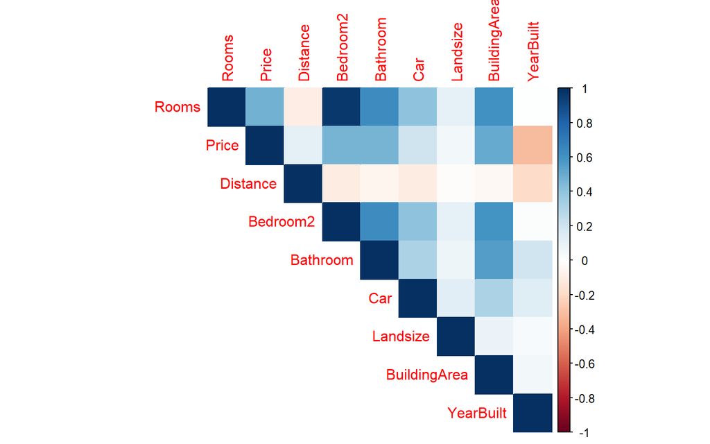

```r
corrplot(cor(numerical), method = "color", type = "upper")
```

From the correlation matrix pairs, pairs involving BuildingArea such as Rooms, Bedrooms2, and Bathrooms have high degrees of correlation. In particular Bedroom2 and Rooms have the highest degree of correlation at 0.96446451. In this case, I have removed Bedroom2 from the model.

### Graph 2

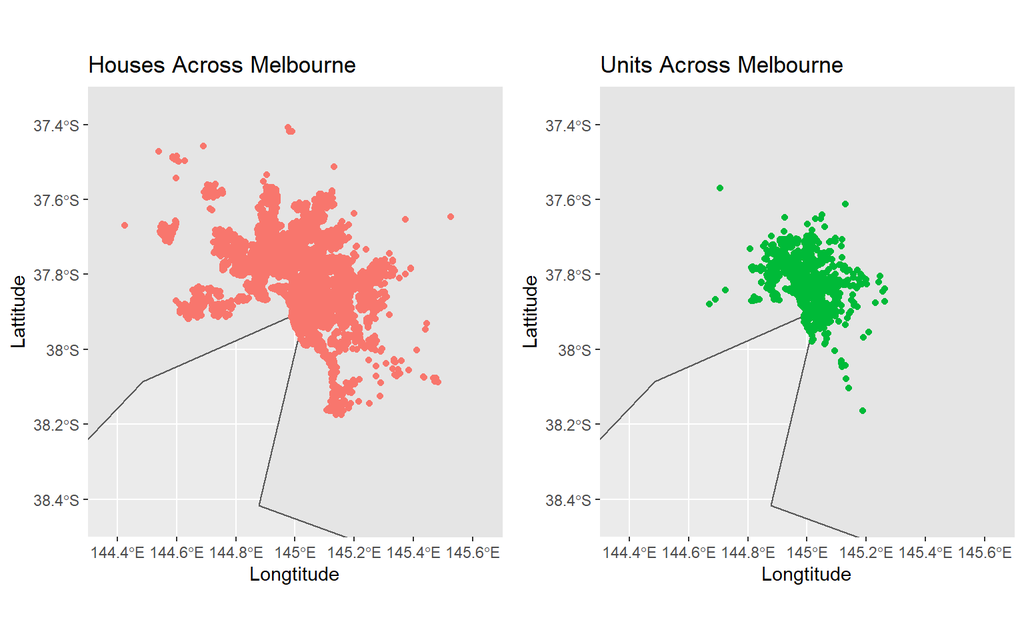

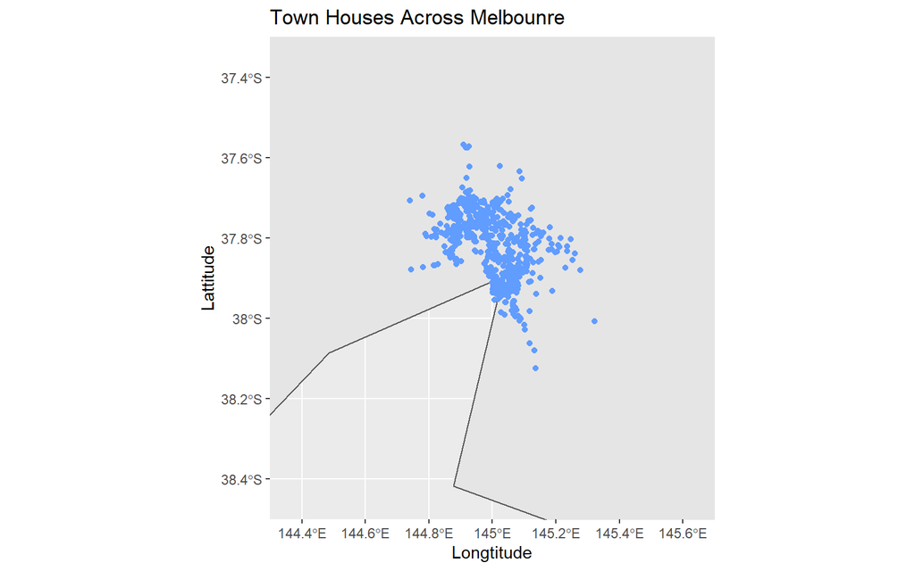

```r
housingType_h <- ggplot() +
  geom_sf(data = world) +
  coord_sf(xlim = c(144.3, 145.7), ylim = c(-38.5, -37.3), expand = FALSE) +
  geom_point(data = type_h, color = '#F8766D',
             aes(x = Longtitude, y = Lattitude)) +
  ggtitle("Houses Across Melbourne")

housingType_t <- ggplot() +
  geom_sf(data = world) +
  coord_sf(xlim = c(144.3, 145.7), ylim = c(-38.5, -37.3), expand = FALSE) +
  geom_point(data = type_t, color = '#619CFF',
             aes(x = Longtitude, y = Lattitude)) +
  ggtitle("Town Houses Across Melbounre")

housingType_u <- ggplot() +
  geom_sf(data = world) +
  coord_sf(xlim = c(144.3, 145.7), ylim = c(-38.5, -37.3), expand = FALSE) +
  geom_point(data = type_u, color = '#00BA38',
             aes(x = Longtitude, y = Lattitude)) +
  ggtitle("Units Across Melbourne")
```

These graphs show the locations of homes across Melbourne. Similar to many city layouts, townhouses and units are centralized towards the center. Houses are located in various locations across the city, in the center, the city’s edge as well as suburbs outside. We can expect to find homes towards the center to be more expensive.

### Graph 3

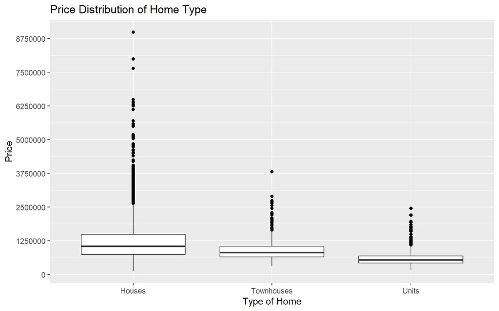

```r
ggplot(housingPrices, aes(Type, Price)) +
  geom_boxplot(outlier.colour = "black") +
  scale_x_discrete(labels = c('Houses','Townhouses','Units')) +
  scale_y_continuous(breaks=seq(0,10000000,1250000)) +
  xlab("Type of Home") +
  ylab("Price") +
  ggtitle("Price Distribution of Home Type")
```

From the graph, we can see that houses have the widest range of prices while units have the smallest. This can be explained by other factors such as building area.

### Graph 4

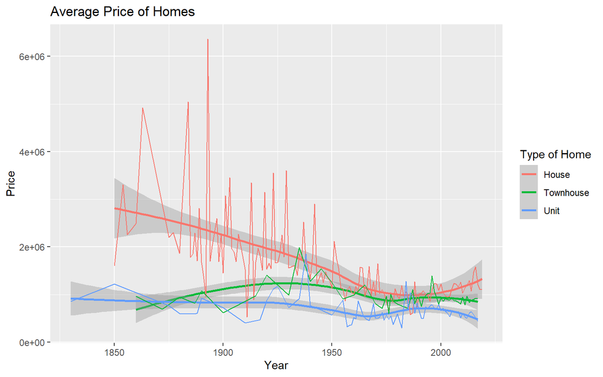

```r
housingPrices %>%
  filter(YearBuilt != 1196) %>%
  select(Price, Type, YearBuilt) %>%
  group_by(YearBuilt, Type) %>%
  summarise(Mean = mean(Price)) %>%
  ggplot(aes(x=YearBuilt, y=Mean, color=Type)) +
  geom_smooth(method = 'loess') +
  geom_line() +
  scale_color_discrete(name = "Type of Home",
                       labels=c("House", "Townhouse", "Unit")) +
  xlab("Year") +
  ylab("Price") +
  ggtitle("Average Price of Homes")
```

Over the years there has been a decrease in average prices of houses, with houses increasing in price around 2000. Average prices of townhouses and units have stayed relatively stable.

### Graph 5

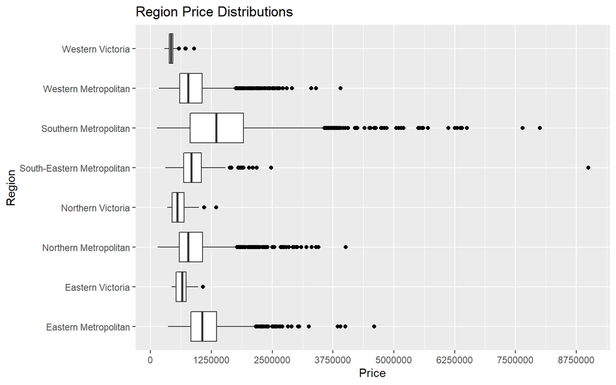

```r
ggplot(housingPrices, aes(Regionname, Price)) +
  geom_boxplot(outlier.colour = "black") +
  scale_y_continuous(breaks=seq(0,10000000,1250000)) +
  theme(legend.position = "none") +
  xlab("Region") +
  ylab("Price") +
  ggtitle("Region Price Distributions") +
  coord_flip()
```

Homes in the Southern Metropolitan region has the highest average price. This makes sense since this region is the center-most region in Melbourne.

### Graph 6

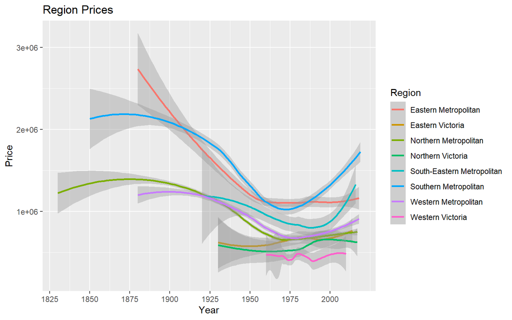

```r
housingPrices %>%
  filter(YearBuilt != 1196) %>%
  ggplot(aes(x=YearBuilt, y=Price, color=Regionname)) +
  scale_x_continuous(breaks=seq(1800,2020,25)) +
  geom_smooth(method = 'loess') +
  xlab("Year") +
  ylab("Price") +
  ggtitle("Region Prices") +
  labs(color = "Region")
```

We can observe the years of region development, with some regions being new or older than others. Homes in the southern regions have the steepest-rise in price post-1975, while other regions have had a relative increase in prices.

### Graph 7

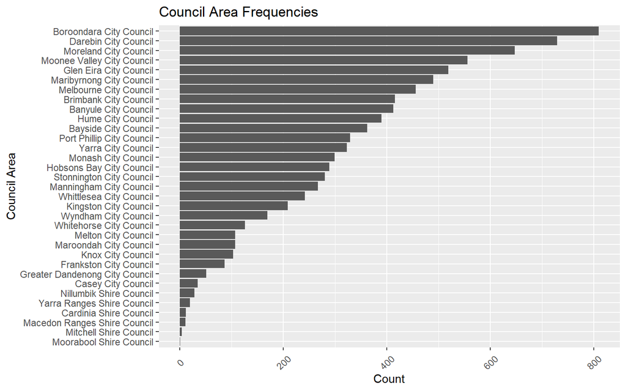

```r
housingPrices %>%
  group_by(CouncilArea) %>%
  summarise(Count = n()) %>%
  ggplot(aes(reorder(CouncilArea, Count), Count)) +
  geom_bar(stat = 'identity') +
  theme(axis.text.x = element_text(angle = 45, vjust = 0.5)) +
  coord_flip() +
  xlab("Council Area") +
  ylab("Count") +
  ggtitle("Council Area Frequencies")
```

There are many council areas with Moorabool Shire having 1 home and Boroondara City having over 800 homes. To reduce the number of levels for this variable I will convert levels with fewer than 103 counts to “Other”.

# Preparing Data

## Feature Engineering and Cleaning

Create BuildingAge feature

```r
housingPrices$BuildingAge <- 2020 - housingPrices$YearBuilt
housingPrices$BuildingAge <- as.integer(housingPrices$BuildingAge)
```

We make building age since the age of a build is easier to interpret than year built.

Reducing category levels

```r
temp <- housingPrices %>%
  select(CouncilArea) %>%
  group_by(CouncilArea) %>%
  count(CouncilArea) %>%
  arrange(desc(n)) %>%
  filter(n <= 103)

housingPrices$CouncilArea <- as.character(housingPrices$CouncilArea)

housingPrices <- housingPrices %>%
  mutate(CouncilArea = replace(CouncilArea, CouncilArea %in% temp[1]$CouncilArea,
                               "Other"))

housingPrices$CouncilArea <- as.factor((housingPrices$CouncilArea))
```

Creating dummy variables

```r
dummy_obj <- dummyVars(~ Type + Regionname, data = housingPrices,
                       sep = ".", levelsOnly = TRUE)
dummies <- predict(dummy_obj, housingPrices)

housingPrices <- cbind(housingPrices, dummies)
housingPrices <- housingPrices %>%
  select(-c(Type, Regionname, CouncilArea, Bedroom2, YearBuilt))
```

## Training and Test Sets

Used logarithmic transformation of response variable to linearize relationship between dependent variables.

```r
set.seed(444)

data$Price <- log(data$Price)
colnames(data) <- make.names(colnames(data))

train_ind <- createDataPartition(y = data$Price, p = 0.8, list = FALSE)

training <- data[train_ind,]
testing <- data[-train_ind,]

X_train <- training %>% select(-Price)
X_test <- testing %>% select(-Price)
Y_train <- training$Price
Y_test <- testing$Price
```

# Modeling

## The Math behind the Metrics

Root Mean Square Error (RMSE) is defined as:

- RMSE = $\sqrt{\frac{\sum_{i=1}^{N}{(\hat{p}-p)^2}}{N}}$
- Where:
  - $\hat{p} =$ predicted values
  - $p =$ observed values
  - $N =$ number of observed values

RMSE is the standard deviation of the average squared residuals. As residuals become smaller, the more accuracy the model is at prediting the dependent variable. When using RMSE, we get the average distance of a data point from the predicted values.

## Notes

- Linear Regression:
  - One of the most widely used models for predicting continuous variables. The model allows for easy interpretation of variable interactions.
- Decision Tree:
  - The simplest tree-based model with the ability to predict both continuous and discrete variables. By splitting leaves via gini criterion, we can narrow down to a predicted value.
- Random Forest;
  - A collection of decision trees with varying splits and sample sizes that creates a robust model. Taking the decision trees, we aggregate the results. One downside of this model, is its interpretation.

## Linear Regression

```r
lm_ctrl <- trainControl(method = "repeatedcv", number = 10, repeats = 10)
fitted_lm <- train(Price~., data = training,
                   trControl = lm_ctrl,
                   metric = "RMSE",
                   method = "lm")
```

```r
fitted_lm$results
```

```
##   intercept      RMSE  Rsquared       MAE      RMSESD RsquaredSD
## 1      TRUE 0.3002365 0.6836686 0.2354856 0.009390415 0.02209392
##         MAESD
## 1 0.006183491
```

After training the model, we get a RMSE of 0.3, as well as other model metrics such as Rsquared at 0.684.

```r
fitted_lm$finalModel$coefficients
```

```
##                (Intercept)                      Rooms
##               1.160200e+01               8.345849e-02
##                   Distance                   Bathroom
##               8.895183e-04               1.357138e-01
##                        Car                   Landsize
##               2.077083e-02               1.289979e-05
##               BuildingArea                BuildingAge
##               1.415478e-03               4.560418e-03
##                          h                          t
##               3.449837e-01               3.213229e-01
##                          u       Eastern.Metropolitan
##                         NA               8.495610e-01
##           Eastern.Victoria      Northern.Metropolitan
##               3.198261e-01               6.889691e-01
##          Northern.Victoria South.Eastern.Metropolitan
##               1.940290e-01               6.377145e-01
##      Southern.Metropolitan       Western.Metropolitan
##               1.059400e+00               6.083303e-01
##           Western.Victoria
##                         NA
```

Looking at the coefficients of each variable, we can see that all variables increase the price of a home. Note, regions are categorical meaning the independent variable is interpreted as a 0 or 1. Living in the Southern Metropolitan increases the price the highest compared to other regions. As for continuous variables, each additional bathroom is valued higher than an individual room.

```r
predict_lm <- predict(fitted_lm, X_test)
residuals <- Y_test - predict_lm
RMSE(predict_lm, Y_test)
```

```
## [1] 0.3057941
```

Using the Linear Regression model we predict prices from the test set. We then compare the predicted values to the observed values to determine our accuracy. The result of the model is an RMSE of 0.306.

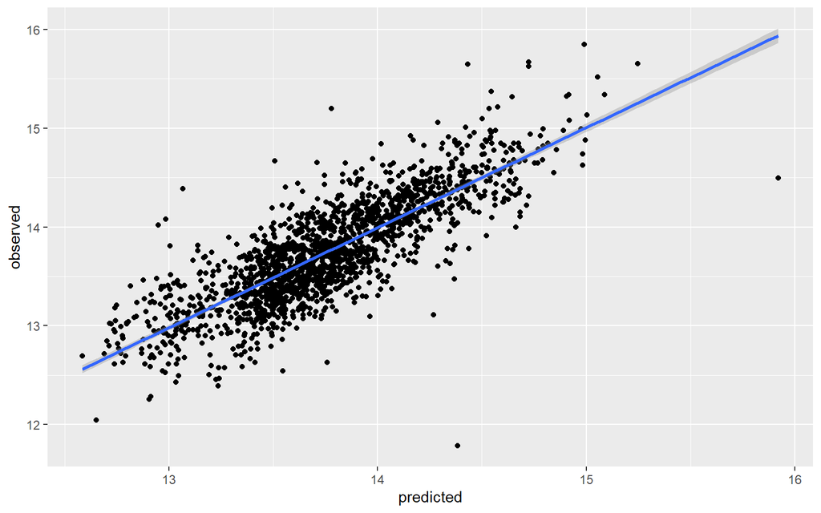

```r
ggplot(lm_data, aes(x = predicted, y = observed)) +
  geom_point() +
  geom_smooth(method = "lm")
```

Plotting the observed and predicted values, we can see that the observed values are clustered around the regression line. This means that the model does well when predicting housing prices. We can also see that there are outliers where the model was not able to take into account.

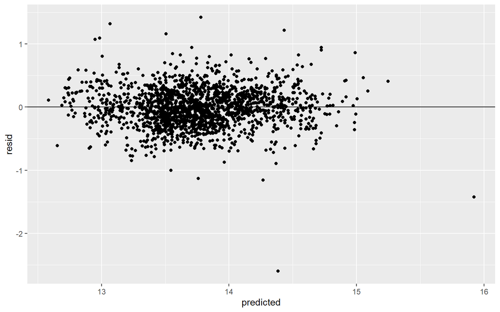

```r
ggplot(lm_data, aes(x = predicted, y = resid)) +
  geom_point() +
  geom_hline(yintercept = 0)
```

When looking at residuals, we can determine model fit by how closely the residuals are to zero. In this case, the residuals are normally distributed with most clustering around zero.

## Decision Tree

```r
dt_ctrl <- trainControl(method = "repeatedcv", number = 10, repeats = 10)
fitted_dt <- train(Price~., data = training,
                   trControl = dt_ctrl,
                   tuneLength = 10,
                   method = "rpart",
                   metric = "RMSE")
```

```r
fitted_dt
```

```
## CART
##
## 7109 samples
##   18 predictor
##
## No pre-processing
## Resampling: Cross-Validated (10 fold, repeated 10 times)
## Summary of sample sizes: 6398, 6398, 6397, 6399, 6397, 6399, ...
## Resampling results across tuning parameters:
##
##   cp          RMSE       Rsquared   MAE
##   0.01369936  0.3341270  0.6082106  0.2600475
##   0.01370926  0.3347553  0.6067052  0.2605815
##   0.01485158  0.3474508  0.5764775  0.2716711
##   0.01512019  0.3498855  0.5704517  0.2736532
##   0.01717110  0.3587466  0.5485252  0.2812465
##   0.03018552  0.3680990  0.5246647  0.2896634
##   0.04792287  0.3821789  0.4876173  0.3027372
##   0.10816361  0.4102792  0.4086089  0.3257725
##   0.11991666  0.4550540  0.2725082  0.3650310
##   0.23875988  0.5016235  0.2202086  0.4048821
##
## RMSE was used to select the optimal model using the smallest value.
## The final value used for the model was cp = 0.01369936.
```

After training using cross-validation, a decision tree of cp = 0.0137 was the best model with an RMSE of 0.334.

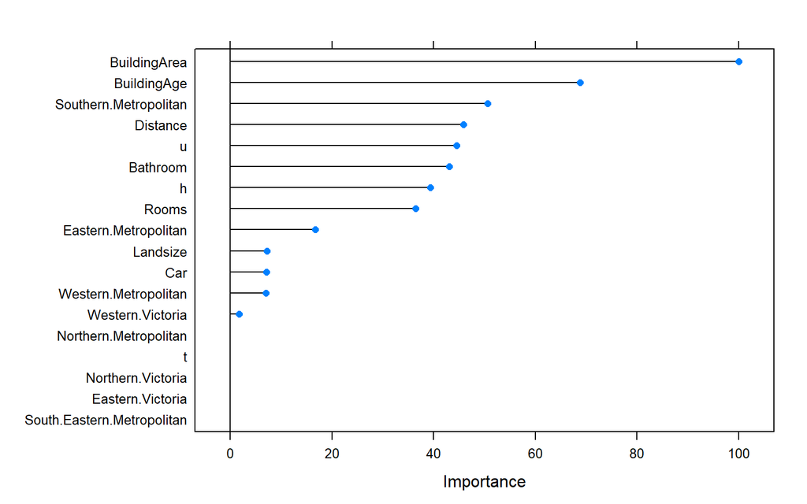

```r
plot(varImp(fitted_dt))
```

We can plot the variables that the decision tree found important when modeling the data. Regions other than Southern and Eastern Metropolitan are not as important to the decision tree model. Building Area and Age seemed to be highly important when determining housing prices.

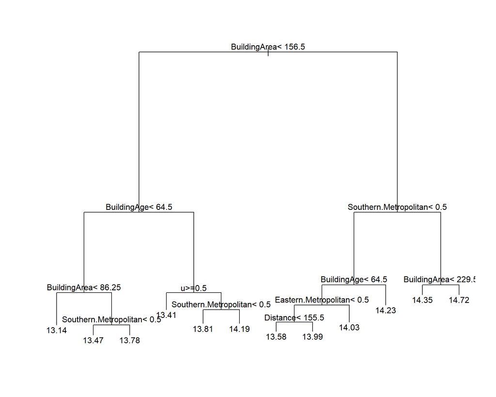

```r
plot(fitted_dt$finalModel)
text(fitted_dt$finalModel)
```

Displays the splits the decision tree made. Remember that the resulting values are logarithmic.

```r
predict_dt <- predict(fitted_dt, X_test)
RMSE(predict_dt, Y_test)
```

```
## [1] 0.3283778
```

Both training and testing RMSE values are relatively close resulting in a good fitted model.

## Random Forest

```r
rf_ctrl <- trainControl(method = "cv", number = 5)
fitted_rf <- train(Price~., data = training,
                   trControl = rf_ctrl,
                   tuneLength = 10,
                   method = "ranger",
                   importance = "permutation",
                   metric = "RMSE",
                   verbose = TRUE)
```

```r
fitted_rf
```

```
## Random Forest
##
## 7109 samples
##   18 predictor
##
## No pre-processing
## Resampling: Cross-Validated (5 fold)
## Summary of sample sizes: 5687, 5686, 5687, 5688, 5688
## Resampling results across tuning parameters:
##
##   mtry  splitrule   RMSE       Rsquared   MAE
##    2    variance    0.2600955  0.7986569  0.2020878
##    2    extratrees  0.3138083  0.7112531  0.2471043
##    3    variance    0.2299317  0.8254308  0.1759894
##    3    extratrees  0.2708026  0.7619927  0.2104770
##    5    variance    0.2128267  0.8434564  0.1603434
##    5    extratrees  0.2306086  0.8189106  0.1761111
##    7    variance    0.2097988  0.8465817  0.1570112
##    7    extratrees  0.2171454  0.8366457  0.1641152
##    9    variance    0.2101509  0.8455991  0.1565115
##    9    extratrees  0.2128535  0.8422832  0.1603439
##   10    variance    0.2101650  0.8455484  0.1564168
##   10    extratrees  0.2122350  0.8430134  0.1598128
##   12    variance    0.2114137  0.8434788  0.1567612
##   12    extratrees  0.2108190  0.8449018  0.1585938
##   14    variance    0.2126107  0.8416323  0.1574236
##   14    extratrees  0.2103494  0.8454513  0.1581500
##   16    variance    0.2145489  0.8385733  0.1584715
##   16    extratrees  0.2097665  0.8462605  0.1576521
##   18    variance    0.2171910  0.8344800  0.1602920
##   18    extratrees  0.2101149  0.8456528  0.1578560
##
## Tuning parameter 'min.node.size' was held constant at a value of 5
## RMSE was used to select the optimal model using the smallest value.
## The final values used for the model were mtry = 16, splitrule =
##  extratrees and min.node.size = 5.
```

The model found mtry = 16, splitrule = extratrees and min.node.size = 5 to be the best model. Obtaining a RMSE of 0.21.

```r
print(fitted_rf$finalModel)
```

```
## Ranger result
##
## Call:
##  ranger::ranger(dependent.variable.name = ".outcome", data = x,      mtry = min(param$mtry, ncol(x)), min.node.size = param$min.node.size,      splitrule = as.character(param$splitrule), write.forest = TRUE,      probability = classProbs, ...)
##
## Type:                             Regression
## Number of trees:                  500
## Sample size:                      7109
## Number of independent variables:  18
## Mtry:                             16
## Target node size:                 5
## Variable importance mode:         permutation
## Splitrule:                        extratrees
## Number of random splits:          1
## OOB prediction error (MSE):       0.04243568
## R squared (OOB):                  0.8511036
```

This output tells the model parameters found to be the most optimal for the model.

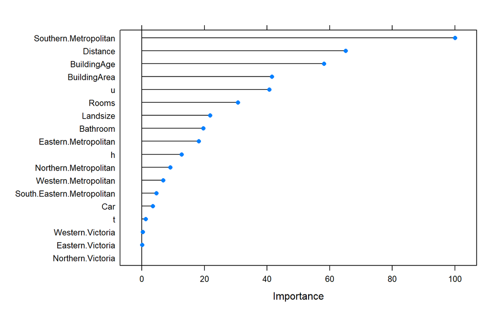

```r
plot(varImp(fitted_rf))
```

Similar to the decision tree, regions other than Southern and Eastern Metropolitan is not as important to the model. The model places Southern Metropolitan, Distance, and Age to be the top 3 variables of importance.

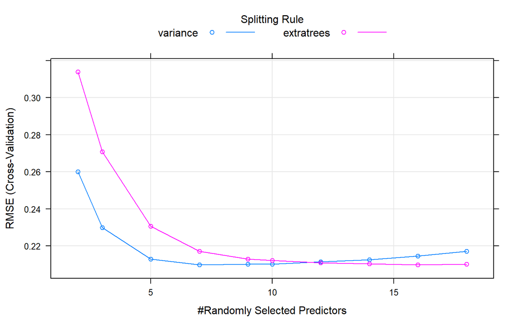

```r
plot(fitted_rf)
```

```r
predict_rf <- predict(fitted_rf, X_test)
RMSE(predict_rf, Y_test)
```

```
## [1] 0.2130286
```

Choosing from the models, random forests produces the better model for regression given the data.

## Modified Random Forest

```r
varImp(fitted_rf)
```

```
## ranger variable importance
##
##                             Overall
## Southern.Metropolitan      100.0000
## Distance                    65.0784
## BuildingAge                 58.1546
## BuildingArea                41.5330
## u                           40.7269
## Rooms                       30.7069
## Landsize                    21.7763
## Bathroom                    19.6043
## Eastern.Metropolitan        18.1486
## h                           12.6545
## Northern.Metropolitan        9.0358
## Western.Metropolitan         6.8239
## South.Eastern.Metropolitan   4.6102
## Car                          3.4245
## t                            1.2254
## Western.Victoria             0.3138
## Eastern.Victoria             0.0129
## Northern.Victoria            0.0000
```

The random forest model does the best when the number of variables are the same across the models. Taking into account the variables that the random forest found to be important, we can reduce the number of variables to attempt to get a lower complexity model.

```r
training <- training %>%
  select(Price, Southern.Metropolitan, u, BuildingAge, BuildingArea, Distance, Rooms, h, Bathroom, Landsize, Eastern.Metropolitan)
testing <- testing %>%
  select(Price, Southern.Metropolitan, u, BuildingAge, BuildingArea, Distance, Rooms, h, Bathroom, Landsize, Eastern.Metropolitan)
```

```r
X_train <- training %>% select(-Price)
X_test <- testing %>% select(-Price)
Y_train <- training$Price
Y_test <- testing$Price
```

```r
rf_ctrl <- trainControl(method = "cv", number = 5)
fitted_mod_rf <- train(Price~., data = training,
                       trControl = rf_ctrl,
                       tuneLength = 10,
                       method = "ranger",
                       importance = "permutation",
                       metric = "RMSE",
                       verbose = TRUE)
```

```r
fitted_mod_rf
```

```
## Random Forest
##
## 7109 samples
##   10 predictor
##
## No pre-processing
## Resampling: Cross-Validated (5 fold)
## Summary of sample sizes: 5686, 5687, 5687, 5688, 5688
## Resampling results across tuning parameters:
##
##   mtry  splitrule   RMSE       Rsquared   MAE
##    2    variance    0.2374674  0.8123767  0.1821591
##    2    extratrees  0.2716851  0.7620033  0.2110338
##    3    variance    0.2219717  0.8293601  0.1676251
##    3    extratrees  0.2386373  0.8055429  0.1823262
##    4    variance    0.2190615  0.8324510  0.1645177
##    4    extratrees  0.2262262  0.8224087  0.1711820
##    5    variance    0.2186164  0.8327761  0.1637301
##    5    extratrees  0.2222768  0.8277531  0.1677277
##    6    variance    0.2190186  0.8319478  0.1635015
##    6    extratrees  0.2207627  0.8297823  0.1664400
##    7    variance    0.2201646  0.8300585  0.1638995
##    7    extratrees  0.2197379  0.8312017  0.1656097
##    8    variance    0.2215005  0.8279140  0.1644014
##    8    extratrees  0.2195234  0.8314407  0.1654585
##    9    variance    0.2234937  0.8247466  0.1657333
##    9    extratrees  0.2189655  0.8322435  0.1649935
##   10    variance    0.2257624  0.8211585  0.1671400
##   10    extratrees  0.2189293  0.8322003  0.1648522
##
## Tuning parameter 'min.node.size' was held constant at a value of 5
## RMSE was used to select the optimal model using the smallest value.
## The final values used for the model were mtry = 5, splitrule =
##  variance and min.node.size = 5.
```

After cross-validation, the optimal model was mtry = 5, splitrule = variance and min.node.size = 5 with a RMSE of 0.219. This result is slightly worse than the original random forest model.

```r
print(fitted_mod_rf$finalModel)
```

```
## Ranger result
##
## Call:
##  ranger::ranger(dependent.variable.name = ".outcome", data = x,      mtry = min(param$mtry, ncol(x)), min.node.size = param$min.node.size,      splitrule = as.character(param$splitrule), write.forest = TRUE,      probability = classProbs, ...)
##
## Type:                             Regression
## Number of trees:                  500
## Sample size:                      7109
## Number of independent variables:  10
## Mtry:                             5
## Target node size:                 5
## Variable importance mode:         permutation
## Splitrule:                        variance
## OOB prediction error (MSE):       0.04637717
## R squared (OOB):                  0.8372739
```

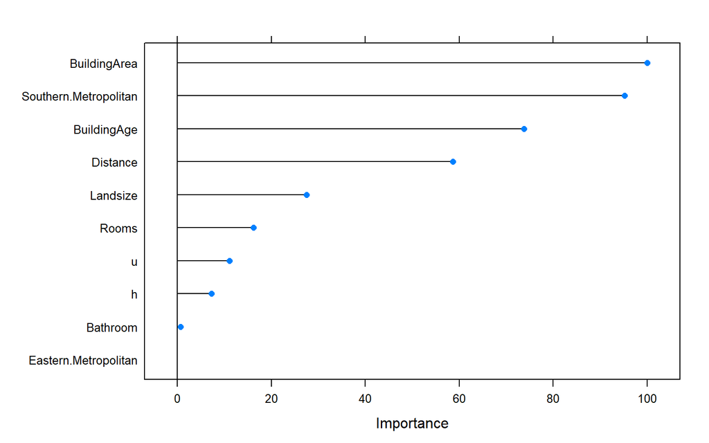

```r
plot(varImp(fitted_mod_rf))
```

Interestingly enough, the model found Eastern Metropolitan to be not important.

```r
predict_mod_rf <- predict(fitted_mod_rf, X_test)
RMSE(predict_mod_rf, Y_test)
```

```
## [1] 0.2210257
```

Using the testing data, the model obtained a RMSE of 0.221, which does slightly worse than the original model with the benefit of lower complexity.

# Final Model

```r
results <- matrix(c(lm_result, dt_result, rf_result, mod_rf_result),ncol=4, byrow=TRUE)
colnames(results) <- c("LR", "DT", "RF", "Modified RF")
rownames(results) <- c("RMSE")
results <- as.table(results)
results
```

```
##             LR        DT        RF Modified RF
## RMSE 0.3057941 0.3283778 0.2130286   0.2210257
```

Interestingly, the linear regression model performed better than the decision tree model. Both being simpler models, linear regression is widely known and studied and much easier to interpret than the decision tree.

# Conclusion

In general, we found that home prices increased with all variables. The only difference is the influence of each variable.

Variables that impacted housing prices the most were:

- Homes located in Southern Metropolitan region
- Age of the home
- Building area
- Distance from city center

Using this information, an individual can price their home based off these variables.